# Bonus Exercise: Dynamic CAPM with INLA

Time-Varying Coefficients in a Bayesian Linear Model

Author

Alexander Massey

Published

March 30, 2026

**NoteOverview**

In standard CAPM, a stock’s return is modelled as:

$$r_{\text{asset}}(t) = \alpha + \beta \cdot r_{\text{market}}(t) + \varepsilon(t)$$

where $\alpha$ (Jensen’s alpha) measures excess return and $\beta$ measures market sensitivity. Fitting a classical linear model has two main problems:

1. Coefficients would be **fixed** over time (not realistic).
2. Ignoring serial correlation yields unbiased estimates but the CIs would be way too narrow.

In this exercise, you will address both these issues by fitting a **dynamic CAPM** in which $\alpha(t)$ and $\beta(t)$ evolve over time as latent AR(1) processes. In a preview of tomorrow’s lessons, you will use **INLA**, which is a remarkably fast and powerful software based on Laplace Approximations instead of MCMC. It is definitely a tool to keep on your radar.

## 1 Background: Why Time-Varying?

Financial markets are non-stationary. A stock’s relationship with the broader market changes due to:

- Shifts in business model or sector composition
- Macroeconomic regime changes (e.g. COVID, wars, criminal bankers)
- Changes in leverage or capital structure

A static beta estimated over 10 years may be meaningless for any particular sub-period. The **state space** approach lets the data tell us when and how these parameters shift.

### 1.1 The Model

$$r_{\text{asset}}(t) = \alpha(t) + \beta(t) \cdot r_{\text{market}}(t) + \varepsilon(t), \quad \varepsilon(t) \sim \mathcal{N}(0, \sigma^2_\varepsilon)$$

with latent processes:

$$\alpha(t) \mid \alpha(t-1) \sim \mathcal{N}(\rho_\alpha \cdot \alpha(t-1),\ \sigma^2_\alpha)$$
$$\beta(t) \mid \beta(t-1) \sim \mathcal{N}(\rho_\beta \cdot \beta(t-1),\ \sigma^2_\beta)$$

When $\rho = 1$ this is a **random walk**; when $|\rho| < 1$ it is a mean-reverting **AR(1)**. INLA estimates all hyperparameters ($\rho$, $\sigma^2_\alpha$, $\sigma^2_\beta$, $\sigma^2_\varepsilon$) jointly with the latent states.

### 1.2 Why INLA and not brms?

| Feature | INLA | brms / Stan |
| --- | --- | --- |
| Speed | Seconds (Laplace approx.) | Minutes (MCMC) |
| Reproducibility | Deterministic | Random seed dependent |
| Scalability | Sparse precision matrices | Dense covariance |
| Flexibility | Latent Gaussian models | Arbitrary posteriors |

INLA is ideal here because the model is a **latent Gaussian model** — the latent states are Gaussian conditional on hyperparameters, which is exactly the class INLA is designed for.

## 2 Data

We use daily log returns from Yahoo Finance. Log returns are approximately stationary (unlike prices), supporting the AR(1) assumption on the latent states.

The **market benchmark** is **VT** (Vanguard Total World ETF), but another common choice would be the S&P 500 . KO is Coca-Cola. GLD is an ETF that tracks the price of gold. LVMHF is a European luxury stock with moderate market exposure. NVDA is a high-growth tech stock whose market cap is currently 4% of the total world market cap. VGK is a broad European ETF. VXUS tracks non-US international equities. Add your own ticker if you like but must trade on the NYSE.

```r
library(KFAS)
library(INLA)
library(ggplot2)
library(quantmod)

tickers <- c("KO", "MCD", "LVMHF", "VGK", "GLD", "NVDA", "VT", "VXUS", "^GSPC")

getSymbols(tickers, src = "yahoo", from = "2010-01-01", to = Sys.Date())
```

```
[1] "KO"    "MCD"   "LVMHF" "VGK"   "GLD"   "NVDA"  "VT"    "VXUS"  "GSPC"
```

```r
stock_returns <- merge(
  dailyReturn(Ad(KO),    type = "log"),
  dailyReturn(Ad(MCD),   type = "log"),
  dailyReturn(Ad(LVMHF), type = "log"),
  dailyReturn(Ad(VGK),   type = "log"),
  dailyReturn(Ad(GLD),   type = "log"),
  dailyReturn(Ad(NVDA),  type = "log"),
  dailyReturn(Ad(VT),    type = "log"),
  dailyReturn(Ad(VXUS),  type = "log"),
  dailyReturn(Ad(GSPC),  type = "log")
)
colnames(stock_returns) <- c("COKE", "MCD", "LVMHF", "VGK", "GLD", "NVDA", "VT", "VXUS", "SP500")

head(stock_returns)
```

```
                    COKE          MCD LVMHF          VGK           GLD
2010-01-04  0.0000000000  0.000000000    NA  0.000000000  0.0000000000
2010-01-05 -0.0121704767 -0.007674681    NA -0.001602020 -0.0009112174
2010-01-06 -0.0003552897 -0.013737291    NA  0.005996382  0.0163649527
2010-01-07 -0.0024882209  0.007296117    NA -0.006397623 -0.0062070314
2010-01-08 -0.0186819327 -0.000970187    NA  0.009978268  0.0049507554
2010-01-11  0.0201047545  0.007731933    NA  0.007911384  0.0132014737
                   NVDA           VT VXUS        SP500
2010-01-04  0.000000000  0.000000000   NA 0.0000000000
2010-01-05  0.014497327  0.002943227   NA 0.0031108320
2010-01-06  0.006375899  0.004962020   NA 0.0005453719
2010-01-07 -0.019792222 -0.003831887   NA 0.0039932184
2010-01-08  0.002158649  0.006527874   NA 0.0028775831
2010-01-11 -0.014115167  0.003136230   NA 0.0017452316
```

## 3 Model Fitting Functions

The helper functions below fit the dynamic CAPM and extract posterior summaries. You will be asked to modify them in the exercises below.

```r
# Fit the dynamic CAPM for one asset against a chosen market benchmark.
# model_alpha and model_beta control the latent process structure:
#   "ar1"  — mean-reverting AR(1) with estimated rho and precision
#   "rw1"  — random walk (integrated process, non-stationary)
#   "iid"  — independent draws (no temporal dependence)
fit_dynamic_capm <- function(data,
                             target_asset,
                             benchmark,
                             model_alpha = "ar1",
                             model_beta  = "ar1") {
  df            <- as.data.frame(data)
  df$y          <- df[[target_asset]]
  df$benchmark  <- df[[benchmark]]
  df$time_alpha <- 1:nrow(df)
  df$time_beta  <- 1:nrow(df)

  fit <- inla(
    y ~ -1 +
      f(time_alpha, model = model_alpha) +
      f(time_beta,  benchmark, model = model_beta),
    family = "gaussian",
    data   = df
  )

  list(fit = fit, target_asset = target_asset, dates = index(data))
}

# Extract posterior means and 95% credible intervals into a tidy data frame.
extract_capm <- function(model_fit) {
  ra <- model_fit$fit$summary.random$time_alpha
  rb <- model_fit$fit$summary.random$time_beta
  data.frame(
    time        = model_fit$dates,
    ticker      = model_fit$target_asset,
    alpha_mean  = ra$mean,
    alpha_lower = ra$`0.025quant`,
    alpha_upper = ra$`0.975quant`,
    beta_mean   = rb$mean,
    beta_lower  = rb$`0.025quant`,
    beta_upper  = rb$`0.975quant`
  )
}
```

```r
# Plotting wrapper: single asset or side-by-side comparison.
# param = "beta" or "alpha"
# n_days controls how many trading days to show (252 ≈ 1 year)
plot_capm <- function(df1, df2 = NULL,
                      param  = c("beta", "alpha"),
                      n_days = 252 * 10) {
  param <- match.arg(param)

  if (param == "alpha") {
    mean_col    <- "alpha_mean"
    lower_col   <- "alpha_lower"
    upper_col   <- "alpha_upper"
    hline       <- 0
    hline_col   <- "red"
    ylab        <- expression(alpha(t))
    title_param <- "Alpha"
  } else {
    mean_col    <- "beta_mean"
    lower_col   <- "beta_lower"
    upper_col   <- "beta_upper"
    hline       <- 1
    hline_col   <- "blue"
    ylab        <- expression(beta(t))
    title_param <- "Beta"
  }

  if (is.null(df2)) {
    df       <- tail(df1, n_days)
    fill_col <- if (param == "alpha") "pink" else "lightblue"

    ggplot(df, aes(x = time)) +
      geom_ribbon(aes(ymin = .data[[lower_col]], ymax = .data[[upper_col]]),
                  fill = fill_col, alpha = 0.4) +
      geom_line(aes(y = .data[[mean_col]]), color = "black", linewidth = 0.9) +
      geom_hline(yintercept = hline, color = hline_col, linetype = "dashed") +
      labs(title    = paste("Time-Varying", title_param, "—", unique(df$ticker)),
           subtitle = "Posterior mean with 95% credible interval",
           x = NULL, y = ylab) +
      theme_minimal(base_size = 13)

  } else {
    combined <- rbind(tail(df1, n_days), tail(df2, n_days))
    tickers  <- unique(combined$ticker)
    colours  <- c("steelblue", "goldenrod")
    names(colours) <- tickers

    ggplot(combined, aes(x = time, fill = ticker, color = ticker)) +
      geom_ribbon(aes(ymin = .data[[lower_col]], ymax = .data[[upper_col]]),
                  alpha = 0.25, color = NA) +
      geom_line(aes(y = .data[[mean_col]]), linewidth = 0.8) +
      geom_hline(yintercept = hline, color = hline_col, linetype = "dashed") +
      scale_fill_manual(values  = colours) +
      scale_color_manual(values = colours) +
      labs(title    = paste("Time-Varying", title_param, "—",
                            tickers[1], "vs", tickers[2]),
           subtitle = "Posterior mean with 95% credible interval | Market: VT",
           x = NULL, y = ylab,
           fill = NULL, color = NULL) +
      theme_minimal(base_size = 13) +
      theme(legend.position = "top")
  }
}
```

## 4 Fitting the Models

We fit the dynamic CAPM for several assets. This may take a minute or two per asset.

```r
df_nvda  <- fit_dynamic_capm(stock_returns, "NVDA",  "VT") |> extract_capm()
df_gld   <- fit_dynamic_capm(stock_returns, "GLD",   "VT") |> extract_capm()
df_mcd   <- fit_dynamic_capm(stock_returns, "MCD",   "VT") |> extract_capm()
df_coke  <- fit_dynamic_capm(stock_returns, "COKE",  "VT") |> extract_capm()
df_vgk   <- fit_dynamic_capm(stock_returns, "VGK",   "VT") |> extract_capm()
df_sp500 <- fit_dynamic_capm(stock_returns, "SP500", "VT") |> extract_capm()
df_lvmh  <- fit_dynamic_capm(stock_returns, "LVMHF", "VT") |> extract_capm()
```

## 5 Example Plots

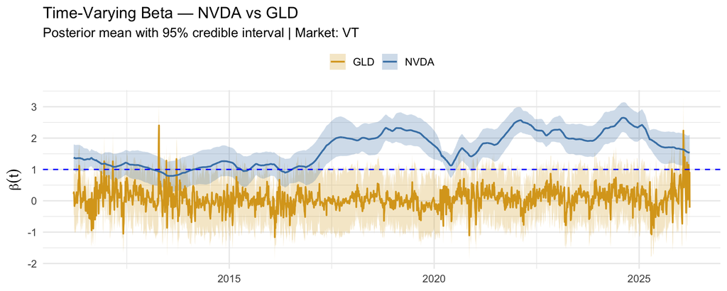

NVDA vs GLD: time-varying beta. NVDA is a high-growth tech stock; GLD is a commodity hedge. Why is beta=0 desireable for a hedge? What does beta>1 indicate?

```r
plot_capm(df_nvda, df_gld, param = "beta", n_days = 252 * 15)
```

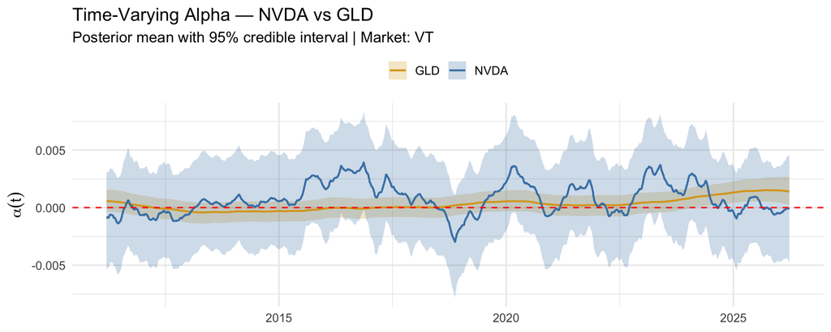

NVDA vs GLD: time-varying alpha.

```r
plot_capm(df_nvda, df_gld, param = "alpha", n_days = 252 * 15)
```

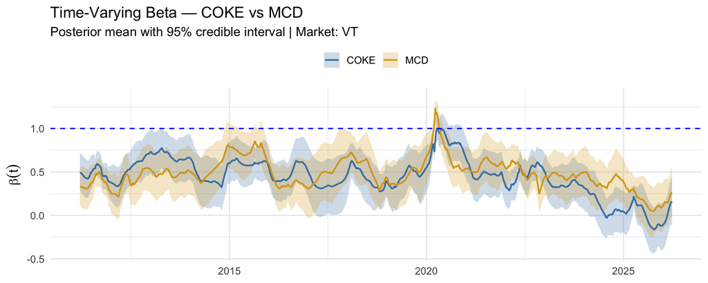

Coca-Cola vs McDonald’s: two defensive consumer staples. Why do their betas move together?

```r
plot_capm(df_coke, df_mcd, param = "beta", n_days = 252 * 15)
```

## 6 Exercises

### 6.1 Exercise 1 — Interpret the Beta Trajectories

Look at the NVDA vs GLD beta plot above.

**TipHint**

Beta measures the sensitivity of the asset’s return to the market. A beta > 1 means the asset moves more than the market; beta < 1 means it moves less; beta < 0 means it tends to move against the market.

**Q1.1.** During the 2020 COVID crash (early 2020), what happens to NVDA’s beta? What does this mean for an investor using NVDA as a hedge?

**Q1.2.** Does GLD’s beta ever go negative? If so, during which periods, and what is the economic interpretation?

**Q1.3.** Look at the credible intervals. Are they wider for NVDA or GLD? What drives the width of a credible interval in this model?

### 6.2 Exercise 2 — iid vs AR(1) Structure

The `fit_dynamic_capm()` function accepts a `model_alpha` and `model_beta` argument. By default both are `"ar1"`. Try changing one or both to `"iid"`.

```r
# Fit NVDA with iid structure on beta (no temporal smoothing)
df_nvda_iid <- fit_dynamic_capm(
  stock_returns, "NVDA", "VT",
  model_beta = "iid"   # <-- change this
) |> extract_capm()

# Compare the two
plot_capm(df_nvda_iid, param = "beta", n_days = 252 * 10)
plot_capm(df_nvda,     param = "beta", n_days = 252 * 10)
```

**Q2.1.** How does the posterior mean of $\beta(t)$ differ between the `iid` and `ar1` specifications? Which is smoother, and why?

**Q2.2.** How do the credible intervals compare? Under `iid`, each time point is estimated independently with no borrowing of strength from neighbours. What effect does this have on uncertainty?

**Q2.3.** Which model do you think is more appropriate for financial returns data, and why? Is there a risk of overfitting with `iid`?

**TipHint**

Under `ar1`, the precision matrix for the latent states is **tridiagonal** — each state is conditionally dependent only on its neighbours. Under `iid`, the precision matrix is **diagonal** — states are conditionally independent. The AR(1) structure introduces temporal smoothing as a form of regularisation.

### 6.3 Exercise 3 — Random Walk vs AR(1)

Try `model_beta = "rw1"`. A random walk is an AR(1) with $\rho = 1$ — it has no mean reversion and is non-stationary.

```r
df_nvda_rw <- fit_dynamic_capm(
  stock_returns, "NVDA", "VT",
  model_beta = "rw1"
) |> extract_capm()

plot_capm(df_nvda_rw, param = "beta", n_days = 252 * 10)
```

**Q3.1.** Does the random walk produce more or less smooth estimates than AR(1)?

**Q3.2.** A random walk has no long-run mean. What does this imply about the long-run behaviour of $\beta(t)$ under this model? Is this economically reasonable?

**Q3.3.** Look at the end of the time series. Does the random walk or AR(1) produce wider credible intervals near the boundary? Why might this be?

### 6.4 Exercise 4 — Choosing the Benchmark

So far we have used VT (Total World) as the market. Try replacing it with SP500 (the domestic US index) for NVDA.

```r
df_nvda_sp <- fit_dynamic_capm(
  stock_returns, "NVDA", "SP500"
) |> extract_capm()

# Compare VT vs SP500 as benchmark
plot_capm(df_nvda,    param = "beta", n_days = 252 * 10)
plot_capm(df_nvda_sp, param = "beta", n_days = 252 * 10)
```

**Q4.1.** Does NVDA’s beta change materially when you switch from VT to SP500? What does this tell you about the correlation between VT and SP500?

**Q4.2.** For a European stock like LVMHF, would you expect a larger difference between VT and SP500 betas? Fit the model and check.

```r
df_lvmh_sp <- fit_dynamic_capm(
  stock_returns, "LVMHF", "SP500"
) |> extract_capm()

plot_capm(df_lvmh,    param = "beta", n_days = 252 * 10)
plot_capm(df_lvmh_sp, param = "beta", n_days = 252 * 10)
```

### 6.5 Exercise 5 — Extracting Hyperparameters

INLA estimates the hyperparameters ($\rho$, precisions) jointly with the latent states. Access them as follows:

```r
# Refit NVDA and keep the full INLA object
nvda_fit <- fit_dynamic_capm(stock_returns, "NVDA", "VT")

# Marginal posteriors for all hyperparameters
nvda_fit$fit$summary.hyperpar
```

**Q5.1.** Find the posterior mean of the AR(1) coefficient $\rho$ for $\beta(t)$. Is it close to 1 (random walk) or closer to 0 (weak persistence)?

**Q5.2.** Compare the precision of the observation noise ($\sigma^2_\varepsilon$) to the precision of the latent beta process ($\sigma^2_\beta$). Which is larger, and what does this imply about the signal-to-noise ratio?

**Q5.3.** Repeat for GLD. Is GLD’s beta process more or less persistent than NVDA’s? Does this match your economic intuition?

### 6.6 Exercise 6 — Extension: Adding a Second Factor *(Challenging)*

The standard CAPM uses a single market factor. The **Fama-French** model adds size (SMB) and value (HML) factors. We can approximate a two-factor model by adding VXUS (international equity) as a second covariate.

```r
# Two-factor model: VT (world market) + VXUS (international tilt)
fit_two_factor <- function(data, target_asset) {
  df              <- as.data.frame(data)
  df$y            <- df[[target_asset]]
  df$market       <- df[["VT"]]
  df$intl         <- df[["VXUS"]]
  df$time_alpha   <- 1:nrow(df)
  df$time_beta1   <- 1:nrow(df)
  df$time_beta2   <- 1:nrow(df)

  inla(
    y ~ -1 +
      f(time_alpha, model = "ar1") +
      f(time_beta1, market, model = "ar1") +
      f(time_beta2, intl,   model = "ar1"),
    family = "gaussian",
    data   = df
  )
}

nvda_2f <- fit_two_factor(stock_returns, "NVDA")
nvda_2f$summary.random$time_beta2 |> head()
```

**Q6.1.** Does adding VXUS as a second factor substantially change the estimated $\beta_{\text{VT}}(t)$ for NVDA?

**Q6.2.** What is the posterior mean of $\beta_{\text{VXUS}}(t)$ for NVDA? Is it credibly different from zero?

**Q6.3.** Why might this two-factor extension be problematic for GLD?

## 7 Summary

**ImportantKey Takeaways**

- The dynamic CAPM relaxes the fixed-parameter assumption of classical CAPM by placing AR(1) priors on the latent $\alpha(t)$ and $\beta(t)$ processes.
- INLA provides fast, deterministic posterior inference via the Laplace approximation — ideal for large time series with latent Gaussian structure.
- The choice of latent process structure (`ar1`, `rw1`, `iid`) acts as a **prior on the smoothness** of the parameter trajectory. This is a modelling choice with substantive economic implications.
- Credible intervals quantify uncertainty about where the parameter is at each point in time — not just whether it differs from a fixed value.
- The choice of benchmark matters: CAPM beta is always relative to a specific market portfolio.

*Applied Bayesian Methods — Bonus Exercise*